# Day 5: Introduction to Numpy

## 4. Why NumPy?

We went through all of this stuff to show you how numpy arrays act similarly to lists, how there are numpy functions that mirror the built-in functions that python has, etc. So why use numpy?

1. Because you can do SO MUCH MORE with a numpy array than a list! In addition to the functions that mirror built-in python functions for lists, there are hundreds of other functions that the numpy developers have made available to us. We will explore some of those here
2. Because there are "array-wise operations" that you can do on numpy arrays that make things way faster and simpler by avoiding for loops.
3. The ability to do linear algebra really easily and quickly on numpy arrays is a result of (1) and (2) - we will check some of that out as well! When you hear that python (and R, and matlab) are "vectorized" languages, this is what that means! You can treat arrays like vectors and matricies instead of dealing with each individual element in the arrays.

## 4.1 Numpy functions

Numpy functions usually have intuitive names. I usually just guess what I think they are called. If I'm wrong, I can just google it!

```python
#lets start out with a 1D array with 10 random elements
arr = np.random.uniform(size=10)
#lets find the standard deviation of elements in the array
print(arr.std())
print(np.std(arr))
#two different ways to call functions on numpy arrays, all of which are valid!
```

```
0.22676866194268755
0.22676866194268755
```

## 4.1.1 Check-in [7]: averages

```python
#now you try: what is the mean of the elements in the array? Guess the function name!
```

### Answer

```python
np.mean(arr) #or, arr.mean()
```

```
0.26137701914252537
```

## 4.1.2 Examples of useful `numpy` functions

```python
#an assortment of useful functions:
med = np.median(arr)
per_90 = np.percentile(arr,90) #90th percentile
summation = np.sum(arr)
print(med, per_90,summation)
```

```
0.251097419891664 0.44455491292735305 2.6137701914252536
```

```python
#you can also do more math with numpy
print(np.exp(arr) )#take e^(all elements in array)
print(np.power(arr,5)) #raise all elements to the 5th power
```

```
[1.24586758 2.30271215 1.02640162 1.33407849 1.07128417 1.32625967
 1.00323971 1.2205136  1.49372575 1.33716274]
[5.13400077e-04 4.03699664e-01 1.20170576e-08 1.98965223e-03
 1.54801346e-06 1.79488503e-03 3.54009996e-13 3.14216334e-04
 1.04040493e-02 2.07063952e-03]
```

## 4.1.3 Numpy functions on `ndarrays`

Unlike lists, ndarrays are truely N-dimensional (you can have lists inside of lists inside of lists, but you cant have a 2D or 3D list. With numpy arrays, you have multi-dimensional objects with multiple *axes*. You can perform operations along those axes.

```python
#lets make a 3x5 array with random variables in it.
arr_2d = np.random.uniform(size=(3,5))
# This array is 2D and we can think of it like a matrix
arr_2d
```

```
array([[0.0833124 , 0.12588925, 0.73937308, 0.54665309, 0.28097398],
       [0.19883202, 0.43469326, 0.71689917, 0.69471867, 0.6031843 ],
       [0.93390934, 0.64611197, 0.47591701, 0.36351978, 0.23012451]])
```

we can think of this array as having an x and y axis. Numpy calls these the 1st and 0th axis. Its reversed from how you might think about it - axis 0 goes down the columns, and axis 1 goes across the rows.

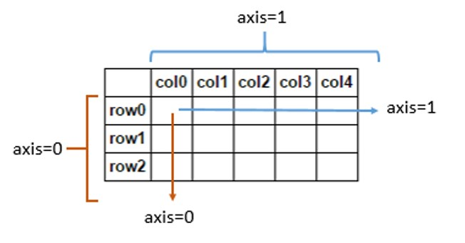

now we can take the mean along the 0th axis. This should return 5 values since we are taking the mean across all rows

```python
arr_2d.mean(axis=0)
```

```
array([0.40535125, 0.40223149, 0.64406309, 0.53496384, 0.37142759])
```

## 4.1.4 Check-in [8] Medians across columns

Paste your answer in the Slack!

```python
# now you try: take the *median* across all columns.
# What axis do you need to choose?

#before you run the cell, predict how many values it should return.
```

We don't *have* to do things along an axis, we can instead do operations on all elements. But it is usually convenient to.

```python
arr_2d.mean() #returns one value, the mean of all elements in all the rows and columns
```

```
0.4716074548129855
```

## 4.1.5 Check-in [9]: apply numpy functions to different axes of arrays with many dimensions

Make a 3x5x7 array of your choosing. You can fill it with random numbers, ones, zeros, tens, you name it. Just make sure they are floats

```python
# find the 20th percentiles along the 0th axis
```

```python
# find the sums along the 2nd axis
```

```python
# find the standard deviations along the 1st axis
```

## 4.2 Array-wise operations

These are faster than for loops. Lets start with an example

## 4.2.1 Summing two arrays

we will add each element of the arrays together in this example, but the same thing works with multiplication, division, raising to a power, etc.

```python
#define two arrays
first_array = np.arange(10)
second_array = np.arange(30,40)
```

```python
#you try: make a new array called sum_array that adds each element of first_array to the same element in second_array.
#lets do this using a for loop and indexing, I'll get it started for you

#this creates an array with the same dimensions as first_array, but filled with zeros. We will fill this in the for loop
sum_array = np.zeros_like(first_array)

#fill in sum_array, element by element
for i in range(len(first_array)):
    the_sum = #fill me in!
    sum_array[i] = the_sum
print(sum_array)
```

that was a lot of code! lets try to do it better with numpy. Since 1D numpy arrays act like vectors, we can add them together with the `+` operator and it will add each component (element) of array 1 to array 2 like this:

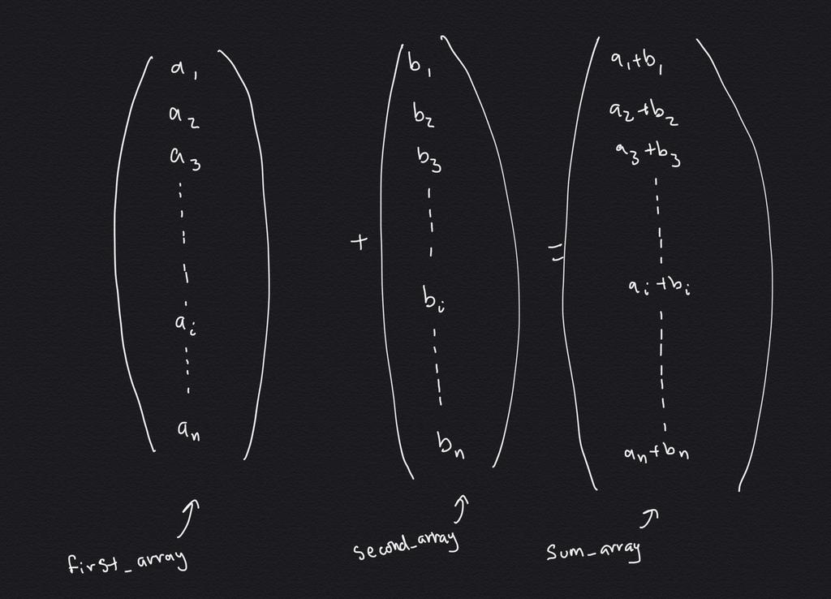

```python
sum_array = first_array + second_array
print(sum_array)
#check to make sure the output is the same as when we used the for loop
```

```
[30 32 34 36 38 40 42 44 46 48]
```

this was a lot less code, and it also takes less computing time. you can't tell with small arrays like these, but when you are working with large datasets, doing things in arrays instead of loops can save you hours of computing time.

Lists don't have these same capabilites, so its best to use numpy arrays

```python
#lists don't do this! they use the + operator to "concatinate", which is rarely what we want
list1 = [56,7]
list2 = [33,2]
list1+list2
```

```
[56, 7, 33, 2]
```

## 4.2.2 Size matching for array-wise operations

quick note: array-wise operations like addition, subtraction, multiplication, and division (`+-*/`) all need to happen between arrays of the same length, or between an array and a scalar.

```python
#try to add arrays of different sizes
third_array = np.arange(60)
first_array + third_array #this returns an error
```

```
---------------------------------------------------------------------------
ValueError                                Traceback (most recent call last)
<ipython-input-64-54fab041c471> in <module>
      1 #try to add arrays of different sizes
      2 third_array = np.arange(60)
----> 3 first_array + third_array #this returns an error

ValueError: operands could not be broadcast together with shapes (10,) (60,)
```

```python
#try to multiply an array and a scalar
first_array*5 #this works fine!
```

```
array([ 0,  5, 10, 15, 20, 25, 30, 35, 40, 45])
```

There are many more array-wise operations that are very useful that we don't have time for today. I'd encourage you to check some out [here](https://scipy-lectures.org/intro/numpy/operations.html) or anywhere else on the web.

## 4.3 Linear Algebra

In numpy, 1d arrays are like vectors and 2d arrays are like matricies. We can do simple linear algebra operations on them easily. This comes in handy when you need to solve systems of equations, approximate integrals, and otherwise combine multiple arrays. Lets check out some of the basic capabilites

```python
#make a 3x4 2d array of your choosing:
arr_linalg = #fill me in!
```